# Statistical report for ACASA-TAVI

AntiCoagulation versus AcetylSalicylic Acid after Transcatheter Aortic Valve Implantation

C. Cunen

19 juni 2026

# 1 Introduction

## 1.1 Randomisation Status

The present dataset is built on *sham randomisation* generated from the most recent export from Viedoc. No true treatment assignments have been unlocked. All findings in this document should therefore be interpreted as preliminary and descriptive only. Final efficacy comparisons will not be conducted until the database is locked and genuine randomisation codes are used.

## 1.2 Data preparations

# 2 Patient enrolment and disposition

27 patients from haukeland, 333 from OUS

## 2.1 Trial population

Table 2.1: Counts

| description | n |
| --- | --- |
| Assessed at screening |  |
| Eligible at screening |  |
| Ineligible at screening |  |
| Eligible and randomised | 359 |
| Eligible not randomised |  |
| Randomized but ineligible | 1 |
| Non-completers | 24 |
| Randomised and FAS | 360 |
| Randomised and FAS with co-primary efficacy endpoint | 334 |
| Randomised and FAS with co-primary safety endpoint | 354 |

## 2.2 Patient disposition (reasons for non-completion)

Overview of study completion and reasons for non-completion. The counts of “Study completed” which are neither “Yes” nor “No” are participants who have not had their final visit yet.

Table 2.2: Overview of study completion and reasons for non-completion

|  | DOAC | ASA | Total |
| --- | --- | --- | --- |
| Number of randomised participants | 180 | 180 | 360 |
| Study completed |  |  |  |
| No | 14 | 10 | 24 |
| Yes | 166 | 170 | 336 |
| Reason for discontinuation |  |  |  |
| Voluntary discontinuation by patient | 4 | 5 | 9 |
| Incorrect randomisation | 1 | 0 | 1 |
| Non-compliance | 1 | 0 | 1 |
| Death | 7 | 5 | 12 |
| Other | 1 | 0 | 1 |

## 2.3 Timing of end of study, withdrawals and follow ups

Time from randomisation to end of study and time from randomisation to withdrawal/lost to follow-up is summarized by median and min-max, overall and by treatment group.

Table 2.3: Length of study by treatment groups

|  | DOAC | ASA | Overall |
| --- | --- | --- | --- |
| All participants | 361 (0-510) | 357 (1-440) | 358.5 (0-510) |
| Non-completers | 31 (0-363) | 183.5 (1-271) | 121 (0-363) |

## 2.4 Protocol deviations

Number of major and minor protocol deviations, summarized by treatment group with details of type of deviation provided.

Table 2.4: Number of minor protocol deviations

| Treatment | Category of PD | n |
| --- | --- | --- |
| DOAC | Incorrect treatment and/or dose | 2 |
| DOAC | Prohibited concomitant medication | 3 |
| DOAC | Failure to collect important data | 6 |
| DOAC | Serious breach - Other | 1 |
| DOAC | Other | 10 |
| ASA | Prohibited concomitant medication | 3 |
| ASA | Failure to collect important data | 4 |
| ASA | Serious breach - SAE notification / safety procedure | 2 |
| ASA | Other | 8 |

There are currently no PD that are categorised as “major”.

Table 2.5: Number of major protocol deviations

| Treatment | Category of PD | n |
| --- | --- | --- |

## 2.5 Adherence to allocated treatment

Number of patients participants switching between ASA and DOAC or stopping the treatment altogether (so far - final data could reveal more switches), by treatment group and in total.

Table 2.6: Number of participants switching or stopping.

|  | No change in study drug | Switching or stopping |
| --- | --- | --- |
| DOAC | 156 | 24 |
| ASA | 157 | 23 |
| Total | 313 | 47 |

## 2.6 Analysis sets

The FAS includes all participants. The SAS is the same as the FAS. The PP includes all participants except – non-completers that did not die (voluntary discontinuation mostly) – participants with important protocol deviations – participants switching between ASA and DOAC or stopping the treatment altogether.

Table 2.7: Number of participants in the different analysis sets.

|  | Full analysis set | Per protocol set |
| --- | --- | --- |
| DOAC | 180 | 152 |
| ASA | 180 | 153 |
| Total | 360 | 305 |

# 3 Demographics and baseline characteristics

## 3.1 Table 1

Table 3.1: Baseline characteristics for all 360 participants. Continuous variables are summarised by mean (SD), or by median (IQR) as appopriate.

| Age (years) | 74.5 (3.7) |
| --- | --- |
| Sex, female | 37% |
| NYHA functional class III or IV | 29% |
| Body mass index (kg/m^2) | 28.1 (4.7) |
| Coronary artery disease | 24% |
| Hypertension | 71% |
| Diabetes mellitus | 28% |
| Previous stroke | 11% |
| Permanent pacemaker | 2% |
| Chronic obstructive pulmonary disease | 14% |
| EuroSCORE II (%) | 2.4 (2.1) |
| Troponin T (ng/L) | 16 (11 - 28) |
| NT-proBNP (ng/L) | 413 (197 - 812) |
| Glomerular filtration rate (mL/min/1 1.73 m^2) | 75 (18.4) |
| Pre-TAVI aortic valve parameters |  |
| Left ventricular ejection fraction (%) | 53.7 (7.7) |
| Aortic valve mean gradient (mmHg) | 49.6 (12.6) |
| Aortic valvular area (cm^2) | 0.8 (0.2) |
| Aortic annular area (mm^2) | 478.4 (93.6) |
| Aortic annular perimeter (mm) | 78.8 (7.7) |
| Bicuspid aortic valve | 14% |
| Valce-in-valve | 2% |
| Procedural characteristics |  |
| Balloon-expanded valve | 71% |
| Self-expandable valve | 29% |
| Pre-dilation | 37% |
| Post-dilation | 9% |

## 3.2 Demographics and medical history

Table 3.2: Demographics and medical history.

| Characteristic | DOAC(n=180) | ASA(n=180) | Overall (n=360) |
| --- | --- | --- | --- |
| Age (years) | 74.4 (3.7) | 74.5 (3.7) | 74.5 (3.7) |
| Sex, n (%) |  |  |  |
| Male | 115 (63.9%) | 111 (61.7%) | 226 (62.8%) |
| Female | 65 (36.1%) | 69 (38.3%) | 134 (37.2%) |
| Hypertension, n (%) |  |  |  |
| Yes | 124 (70.9%) | 126 (72%) | 250 (71.4%) |
| Missing | 5 (2.8%) | 5 (2.8%) | 10 (2.8%) |
| Coronary artery disease, n (%) |  |  |  |
| Yes | 36 (20.6%) | 47 (26.9%) | 83 (23.7%) |
| Missing | 5 (2.8%) | 5 (2.8%) | 10 (2.8%) |
| Diabetes mellitus, n (%) |  |  |  |
| Yes | 54 (30.9%) | 45 (25.7%) | 99 (28.3%) |
| Missing | 5 (2.8%) | 5 (2.8%) | 10 (2.8%) |
| Chronic obstructive pulmonary disease, n (%) |  |  |  |
| Yes | 26 (14.9%) | 22 (12.6%) | 48 (13.7%) |
| Missing | 5 (2.8%) | 5 (2.8%) | 10 (2.8%) |
| Previous stroke, n (%) |  |  |  |
| Yes | 19 (10.9%) | 21 (12%) | 40 (11.4%) |
| Missing | 5 (2.8%) | 5 (2.8%) | 10 (2.8%) |
| Permanent pacemaker |  |  |  |
| Yes | 5 (2.9%) | 3 (1.7%) | 8 (2.3%) |
| Missing | 5 (2.8%) | 5 (2.8%) | 10 (2.8%) |
| Smoking status, n (%) |  |  |  |
| Never smoked | 59 (32.8%) | 66 (36.7%) | 125 (34.7%) |
| Has stopped | 94 (52.2%) | 91 (50.6%) | 185 (51.4%) |
| Sometimes | 1 (0.6%) | 1 (0.6%) | 2 (0.6%) |
| Daily | 26 (14.4%) | 22 (12.2%) | 48 (13.3%) |

## 3.3 Vital signs and physical characteristics at baseline

Table 3.3: Vital signs and physical characteristics at baseline.

| Characteristic | DOAC(n=180) | ASA(n=180) | Overall (n=360) |
| --- | --- | --- | --- |
| Weight (kg) | 84.3 (16.2) | 84.9 (15.9) | 84.6 (16) |
| Height (cm) | 173.8 (9.3) | 173 (9) | 173.4 (9.1) |
| Body mass index (kg/m2) | 27.9 (4.9) | 28.3 (4.5) | 28.1 (4.7) |
| Systolic blood pressure (mmHg) | 137 (19.1) | 143.6 (22) | 140.3 (20.8) |
| Diastolic blood pressure (mmHg) | 71.9 (9.8) | 71.9 (10.4) | 71.9 (10.1) |
| Body temperature (C) | 36.7 (0.4) | 36.7 (0.4) | 36.7 (0.4) |
| Pulse rate (beats/min) | 74.7 (14.6) | 73 (11.6) | 73.8 (13.2) |
| Respiratory rate (breaths/min) | 16.9 (2.9) | 16.8 (2.2) | 16.8 (2.5) |
| Mini-Cog |  |  |  |
| Signs of cognitive impairment (0-2) | 15 (9.3%) | 11 (6.9%) | 26 (8.1%) |
| No cognitive impairment (3-5) | 147 (90.7%) | 148 (93.1%) | 295 (91.9%) |
| Missing | 18 (10%) | 21 (11.7%) | 39 (10.8%) |
| Five times sit-to-stand |  |  |  |
| < 15 sec | 115 (83.3%) | 109 (79.6%) | 224 (81.5%) |
| >= 15 sec | 23 (16.7%) | 28 (20.4%) | 51 (18.5%) |
| Missing | 42 (23.3%) | 43 (23.9%) | 85 (23.6%) |
| Frailty, n (%) |  |  |  |
| Robust | 75 (41.7%) | 90 (50%) | 165 (45.8%) |
| Pre-frail | 59 (32.8%) | 43 (23.9%) | 102 (28.3%) |
| Frail | 0 (0%) | 0 (0%) | 0 (0%) |
| Missing | 46 (25.6%) | 47 (26.1%) | 93 (25.8%) |

## 3.4 Clinical chemistry and hematology at baseline

Table 3.4: Some results related to clinical chemistry and hematology at baseline.

| Characteristic | DOAC(n=180) | ASA(n=180) | Overall (n=360) |
| --- | --- | --- | --- |
| Hemoglobin | 13.4 (1.6) | 13.7 (1.6) | 13.6 (1.6) |
| Platelets | 220.1 (61.7) | 232.9 (67) | 226.5 (64.7) |
| Leukocytes | 7.2 (6.1 - 8.6) | 7.4 (6.5 - 8.7) | 7.3 (6.3 - 8.7) |
| International Normalized Ratio (INR) | 1.1 (0.1) | 1 (0.1) | 1.1 (0.1) |
| Sodium | 139.5 (2.7) | 139.6 (2.8) | 139.6 (2.7) |
| Potassium | 4.1 (0.4) | 4 (0.4) | 4.1 (0.4) |
| ALT | 25.3 (13.3) | 27.6 (13.9) | 26.4 (13.6) |
| Cardiac troponin T | 17 (11.8 - 27.8) | 15 (11 - 28) | 16 (11 - 28) |
| NT-proBNP | 431 (216 - 815) | 372 (177 - 779) | 413 (197 - 812) |
| GFR | 73.6 (19.6) | 76.3 (17.1) | 75 (18.4) |
| Glucose | 6.8 (2) | 6.8 (2.2) | 6.8 (2.1) |
| Glycated haemoglobin (HbA1c) | 42.2 (9.3) | 42 (9.9) | 42.1 (9.6) |
| Triglycerides | 1.6 (0.9) | 1.5 (0.7) | 1.5 (0.8) |
| Missing | 6 (3.3%) | 4 (2.2%) | 10 (2.8%) |
| Total cholesterol | 4.2 (1.1) | 4.3 (1.1) | 4.2 (1.1) |
| HDL cholesterol | 1.4 (0.4) | 1.5 (0.5) | 1.4 (0.5) |
| LDL cholesterol | 2.2 (0.9) | 2.3 (0.9) | 2.3 (0.9) |
| Creatinine | 92.2 (46.8) | 84.8 (29.4) | 88.5 (39.2) |
| Albumin | 42.7 (3.8) | 43 (2.8) | 42.9 (3.3) |
| Missing | 6 (3.3%) | 4 (2.2%) | 10 (2.8%) |
| Bilirubin | 8.9 (4.5) | 9.9 (5.6) | 9.4 (5.1) |
| Missing | 6 (3.3%) | 4 (2.2%) | 10 (2.8%) |
| CRP | 1.6 (0.8 - 4) | 1.4 (0.7 - 3.3) | 1.5 (0.8 - 3.8) |

## 3.5 Echocardiography pre-TAVI and at baseline

Table 3.5: Some echocardiography parameters pre-TAVI.

| Characteristic | DOAC(n=180) | ASA(n=180) | Overall (n=360) |
| --- | --- | --- | --- |
| Aortic valve mean gradient (mmHg) | 49.4 (13.2) | 49.9 (12) | 49.6 (12.6) |
| LVOT (mm) | 22.7 (1.8) | 22.3 (1.9) | 22.5 (1.9) |
| Presence of low-flow low-gradient | 9 (5.3%) | 9 (5.2%) | 18 (5.2%) |
| Left ventricular ejection fraction (%) | 52.9 (7.6) | 54.5 (7.8) | 53.7 (7.7) |
| Left ventricular global longitudinal strain (%) | -15.2 (3.4) | -16.4 (8.9) | -15.8 (6.7) |
| Stroke volume (mL) | 83.7 (19.8) | 86 (22.4) | 84.9 (21.2) |
| Stroke volume index (mL per m^2) | 40.5 (12.6) | 41.1 (14.1) | 40.8 (13.3) |
| Aortic valvular area (cm^2) | 0.8 (0.2) | 0.8 (0.2) | 0.8 (0.2) |
| Aortic valve regurgitation | 108 (63.5%) | 106 (61.6%) | 214 (62.6%) |
| Missing echocardiography | 9 (5%) | 8 (4.4%) | 17 (4.7%) |

Table 3.6: Some echocardiography parameters at baseline (post-TAVI).

| Characteristic | DOAC(n=180) | ASA(n=180) | Overall (n=360) |
| --- | --- | --- | --- |
| Aortic valve mean gradient (mmHg) | 12.7 (4.6) | 13 (4.6) | 12.8 (4.6) |
| LVOT (mm) | 21.2 (2) | 21.1 (2) | 21.1 (2) |
| Presence of low-flow low-gradient | 38 (24.4%) | 30 (18.6%) | 68 (21.5%) |
| Left ventricular ejection fraction (%) | 57.7 (9) | 55.9 (12) | 56.8 (10.7) |
| Left ventricular global longitudinal strain (%) | -15.6 (3.4) | -15.6 (3.4) | -15.6 (3.4) |
| Stroke volume (mL) | 80.1 (15.1) | 82.2 (18.9) | 81.2 (17.2) |
| Stroke volume index (mL per m^2) | 39.5 (8.2) | 40.6 (9.2) | 40.1 (8.7) |
| Aortic valvular area (cm^2) | 1.9 (0.4) | 1.9 (0.5) | 1.9 (0.4) |
| Aortic valve regurgitation | 53 (33.5%) | 53 (32.7%) | 106 (33.1%) |
| Missing echocardiography | 59 (32.8%) | 55 (30.6%) | 114 (31.7%) |

## 3.6 Characteristics of the TAVI procedure

Table 3.7: Characteristics of the TAVI procedure.

| Characteristic | DOAC(n=180) | ASA(n=180) | Overall (n=360) |
| --- | --- | --- | --- |
| TAVI valve type, n (%) |  |  |  |
| Balloon-expanded | 130 (72.6%) | 126 (70%) | 256 (71.3%) |
| Self-expandable | 49 (27.4%) | 54 (30%) | 103 (28.7%) |
| TAVI post-dilatation, n (%) |  |  |  |
| Yes | 13 (7.3%) | 20 (11.1%) | 33 (9.2%) |
| No | 166 (92.7%) | 160 (88.9%) | 326 (90.8%) |
| TAVI supra-valvular prothesis position, n (%) |  |  |  |
| Yes | 46 (25.7%) | 54 (30%) | 100 (27.9%) |
| No | 133 (74.3%) | 126 (70%) | 259 (72.1%) |
| Ascending aorta diameter (mm) | 30.5 (4) | 29.6 (3.8) | 30.1 (3.9) |
| Missing | 0 (0%) | 0 (0%) | 0 (0%) |

# 4 Primary analysis of primary endpoints

## 4.2 Co-primary efficacy endpoint

### 4.2.1 Descriptive statistics

Table 4.1: Descriptive statistics for HALT (primary efficacy endpoint). Counts and proportions.

|  | DOAC | ASA | Overall |
| --- | --- | --- | --- |
| No thickening | 127 | 133 | 260 |
| <=25% of leaflet | 20 | 16 | 36 |
| >25-50 % of leaflet | 13 | 9 | 22 |
| >50-75 % of lealet | 2 | 5 | 7 |
| >75 % of leaflet | 3 | 6 | 9 |
| Missing HALT | 15 | 11 | 26 |
| Death | 7 | 5 | 12 |
| Total HALT | 38 (23%) | 36 (21.3%) | 74 (22.2%) |
| Total HALT & Death | 45 (26.2%) | 41 (23.6%) | 86 (24.9%) |

### 4.2.2 Main analysis: Unadjusted analysis with multiple imputation

Multiple imputation with imputation model containing sex, hemoglobin, potassium, bmi, sodium and LDL cholesterol. So the model does not use the treatment variable (to stay more or less in-line with the protocol). But the analysis model only uses the treatment variable and no other covariates.

Table 4.2: Estimated average unadjusted risk ratio, along with corresponding p-value and confidence interval.

| contrast | estimate | p.value | 95CI_low | 95CI_high |
| --- | --- | --- | --- | --- |
| DOAC / ASA | 1.124 | 0.531 | 0.779 | 1.621 |

## 4.3 Co-primary safety endpoint

### 4.3.1 Descriptive statistics

Table 4.3: Descriptive statistics for primary safety endpoint. Counts and proportions. The counts are the number of participants experiencing an event of a particular type as their *first* safety event. Some patients may experience more than one safety event.

|  | DOAC | ASA | Overall |
| --- | --- | --- | --- |
| No safety events | 159 | 163 | 322 |
| bleeding | 5 | 4 | 9 |
| death | 6 | 5 | 11 |
| mi | 2 | 2 | 4 |
| stroke | 4 | 4 | 8 |
| Missing | 4 | 2 | 6 |
| Total safety event | 17 (9.7%) | 15 (8.4%) | 32 (9%) |

Out of the 32 safety events, 10 happen in patients that also switch between the treatments at some point. Among these 10 patients: 6 experience the safety event before switching, while 4 experience the safety event after switching.

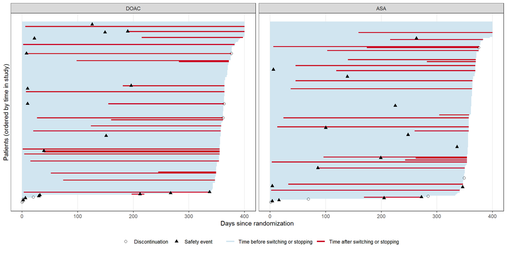

Figure 4.1: All patients

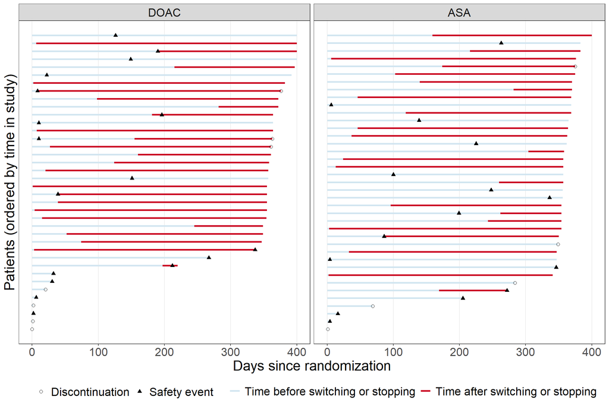

Figure 4.2: Patients with safety events and/or switching and discontinuation

In this figure there are 77 patients, including 32 patients experiencing the safety event, 47 patients with switching/stopping and 12 patients that discontinue* (actually 9 voluntary discontinuation, one incorrect randomisation [very early], and two which are followed for a full year, but have “other” or “non-compliance” listed as end-of-study reason). Some patients are then part of more than one group.

### 4.3.2 Unadjusted analysis with multiple imputation, treatment policy strategy

Multiple imputation with imputation model containing no covariates (so using only the overall event rate, to stay more or less in-line with the protocol). The analysis model uses the treatment variable and no other covariates.

Table 4.4: Estimated average unadjusted risk difference, along with corresponding p-value and confidence interval.

| contrast | estimate | SE | p.value.nonsup | 95CI_low | 95CI_high |
| --- | --- | --- | --- | --- | --- |
| DOAC - ASA | 0.012 | 0.030 | 0.000 | -0.047 | 0.072 |

# 5 Sensitivity analyses of primary endpoints

# 6 Key secondary endpoints

## 6.1 Clinical efficacy

Table 6.1: Descriptive statistics for clinical efficacy composite by treatment arms and overall. Counts and proportions.

|  | DOAC | ASA | Overall |
| --- | --- | --- | --- |
| Missing | 6 | 7 | 13 |
| composite=0 | 129 | 129 | 258 |
| composite=1 | 45 | 44 | 89 |
| composite=1, % | 25.9% | 25.4% | 25.6% |

## 6.2 Thromboembolic events

Table 6.2: Descriptive statistics for thromboembolic events by treatment arms and overall. Counts and proportions.

|  | DOAC | ASA | Overall |
| --- | --- | --- | --- |
| Missing | 8 | 4 | 12 |
| No thromboembolic event | 166 | 170 | 336 |
| With thromboembolic event | 6 | 6 | 12 |
| events, % | 3.5% | 3.4% | 3.4% |

## 6.3 Bleeding events

Table 6.3: Descriptive statistics for VARC-3 bleeding events by treatment arms and overall. Counts and proportions.

|  | DOAC | ASA | Overall |
| --- | --- | --- | --- |
| Missing | 5 | 3 | 8 |
| No bleeding events | 168 | 173 | 341 |
| Type 1 | 5 | 2 | 7 |
| Type 2 | 0 | 0 | 0 |
| Type 3 | 1 | 2 | 3 |
| Type 4 | 1 | 0 | 1 |
| VARC-3 bleeding events | 7 | 4 | 11 |
| events, % | 4% | 2.3% | 3.1% |

## 6.4 All-cause mortality

Table 6.4: Descriptive statistics for deaths by treatment arms and overall. Counts and proportions.

|  | DOAC | ASA | Overall |
| --- | --- | --- | --- |
| Missing | 0 | 0 | 0 |
| Alive at EOS | 173 | 175 | 348 |
| Death from cardiovascular causes | 3 | 4 | 7 |
| Deaths | 7 | 5 | 12 |
| Deaths, % | 3.9% | 2.8% | 3.3% |

## 6.5 Hemodynamic valve deterioration

Table 6.5: Descriptive statistics for HVD by treatment arms and overall. Counts and proportions.

|  | DOAC | ASA | Overall |
| --- | --- | --- | --- |
| Missing | 110 | 114 | 224 |
| No HVD (stage 2 or 3) | 60 | 61 | 121 |
| HVD (stage 2 or 3) | 10 | 5 | 15 |
| HVD (2 or 3), % | 14.3% | 7.6% | 11% |

# 7 Secondary safety endpoints

# 8 Sub-group analyses

## 8.1 HALT

Unadjusted logistic regression (with multiple imputation using same imputation model as in the primary analysis).

### 8.1.1 Age

Table 8.1: Descriptive statistics for HALT (primary efficacy endpoint) in age subgroups. Counts and proportions.

|  | <75 DOAC | <75 ASA | >= 75 DOAC | >= 75 ASA |
| --- | --- | --- | --- | --- |
| no HALT | 53 | 57 | 74 | 76 |
| HALT | 15 | 18 | 23 | 18 |
| Deaths | 3 | 1 | 4 | 4 |
| HALT & Deaths | 25.4% | 25% | 26.7% | 22.4% |

Table 8.2: Estimated average unadjusted risk ratio, along with corresponding p-value and confidence interval.

| contrast | age | estimate | p.value | 95CI_low | 95CI_high |
| --- | --- | --- | --- | --- | --- |
| DOAC / ASA | <75 | 1.037 | 0.899 | 0.596 | 1.804 |
| DOAC / ASA | >= 75 | 1.204 | 0.456 | 0.738 | 1.964 |

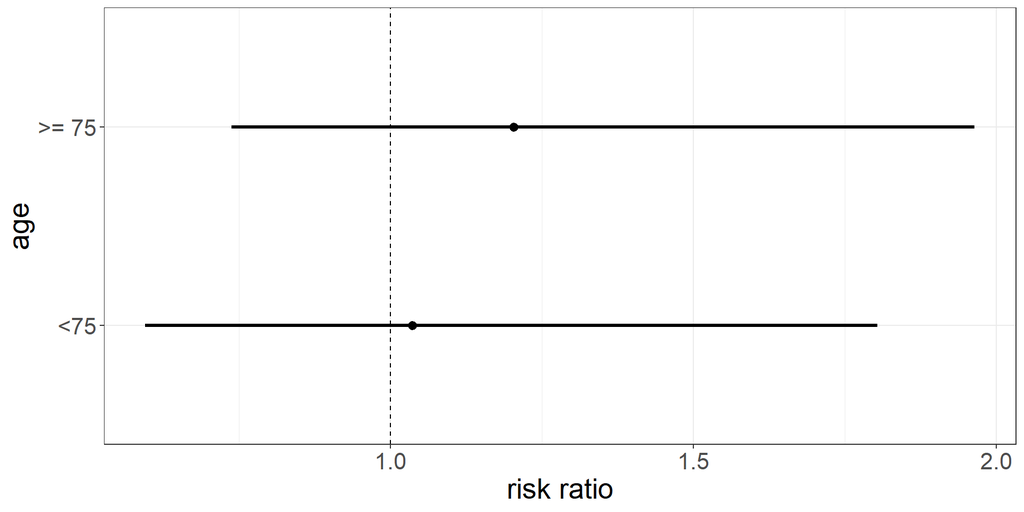

Figure 8.1: Estimated risk ratio between DOAc and ASA in two age groups, with 95% confidence interval.

### 8.1.2 Sex

Table 8.3: Descriptive statistics for HALT (primary efficacy endpoint) by sex. Counts and proportions.

|  | Male DOAC | Male ASA | Female DOAC | Female ASA |
| --- | --- | --- | --- | --- |
| no HALT | 85 | 84 | 42 | 49 |
| HALT | 20 | 21 | 18 | 15 |
| Deaths | 6 | 2 | 1 | 3 |
| HALT & Deaths | 23.4% | 21.5% | 31.1% | 26.9% |

Table 8.4: Estimated average unadjusted risk ratio, along with corresponding p-value and confidence interval.

| contrast | sex | estimate | p.value | 95CI_low | 95CI_high |
| --- | --- | --- | --- | --- | --- |
| DOAC / ASA | Male | 1.103 | 0.699 | 0.671 | 1.811 |
| DOAC / ASA | Female | 1.154 | 0.608 | 0.667 | 1.995 |

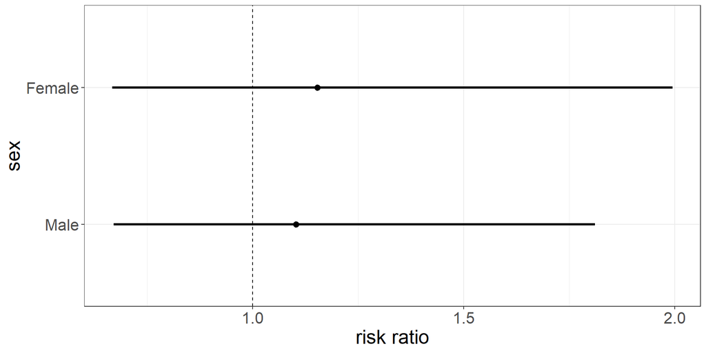

### 8.1.3 Diabetes

Table 8.5: Descriptive statistics for HALT (primary efficacy endpoint) by diabetes. Counts and proportions.

|  | No diabetes DOAC | No diabetes ASA | Diabetes DOAC | Diabetes ASA |
| --- | --- | --- | --- | --- |
| no HALT | 87 | 97 | 36 | 34 |
| HALT | 27 | 24 | 10 | 9 |
| Deaths | 5 | 4 | 2 | 1 |
| HALT & Deaths | 26.9% | 22.4% | 25% | 22.7% |

### 8.1.4 Hypertension

Table 8.6: Descriptive statistics for HALT (primary efficacy endpoint) by hypertension. Counts and proportions.

|  | No hypertension DOAC | No hypertension ASA | Hypertension DOAC | Hypertension ASA |
| --- | --- | --- | --- | --- |
| no HALT | 31 | 36 | 92 | 95 |
| HALT | 14 | 7 | 23 | 26 |
| Deaths | 3 | 2 | 4 | 3 |
| HALT & Deaths | 35.4% | 20% | 22.7% | 23.4% |

### 8.1.5 Impaired renal function

Table 8.7: Descriptive statistics for HALT (primary efficacy endpoint) by renal function. Counts and proportions.

|  | Impaired DOAC | Impaired ASA | Preserved DOAC | Preserved ASA |
| --- | --- | --- | --- | --- |
| no HALT | 6 | 2 | 121 | 131 |
| HALT | 0 | 0 | 38 | 36 |
| Deaths | 1 | 1 | 6 | 4 |
| HALT & Deaths | 14.3% | 33.3% | 26.7% | 23.4% |

> Here there are so few in the impaired group that I don’t think inference is necessary.

### 8.1.6 TAVI valve type

Table 8.8: Descriptive statistics for HALT (primary efficacy endpoint) by valve type. Counts and proportions.

|  | Balloon-expanded DOAC | Balloon-expanded ASA | Self-expandable DOAC | Self-expandable ASA |
| --- | --- | --- | --- | --- |
| no HALT | 95 | 92 | 32 | 41 |
| HALT | 23 | 27 | 15 | 9 |
| Deaths | 7 | 3 | 0 | 2 |
| HALT & Deaths | 24% | 24.6% | 31.9% | 21.2% |

### 8.1.7 TAVI post-dilation

Table 8.9: Descriptive statistics for HALT (primary efficacy endpoint) by post-dilation. Counts and proportions.

|  | No DOAC | No ASA | Yes DOAC | Yes ASA |
| --- | --- | --- | --- | --- |
| no HALT | 119 | 117 | 8 | 16 |
| HALT | 33 | 33 | 5 | 3 |
| Deaths | 7 | 4 | 0 | 1 |
| HALT & Deaths | 25.2% | 24% | 38.5% | 20% |

### 8.1.8 TAVI supra-valcular prosthesis position

Table 8.10: Descriptive statistics for HALT (primary efficacy endpoint) by supra-valcular prosthesis position. Counts and proportions.

|  | No DOAC | No ASA | Yes DOAC | Yes ASA |
| --- | --- | --- | --- | --- |
| no HALT | 97 | 92 | 30 | 41 |
| HALT | 24 | 27 | 14 | 9 |
| Deaths | 7 | 3 | 0 | 2 |
| HALT & Deaths | 24.2% | 24.6% | 31.8% | 21.2% |

### 8.1.9 Ascending aorta diameter

Table 8.11: Descriptive statistics for HALT (primary efficacy endpoint) by ascending aorta diameter (mm). Counts and proportions.

|  | < 30 DOAC | < 30 ASA | >= 30 DOAC | >= 30 ASA |
| --- | --- | --- | --- | --- |
| no HALT | 56 | 70 | 71 | 63 |
| HALT | 15 | 22 | 23 | 14 |
| Deaths | 3 | 2 | 4 | 3 |
| HALT & Deaths | 24.3% | 25.5% | 27.6% | 21.2% |

### 8.1.10 Frailty index

Table 8.12: Descriptive statistics for HALT (primary efficacy endpoint) by frailty category. Counts and proportions.

|  | robust DOAC | robust ASA | pre-frail DOAC | pre-frail ASA | missing DOAC | missing ASA |
| --- | --- | --- | --- | --- | --- | --- |
| no HALT | 57 | 64 | 38 | 36 | 32 | 33 |
| HALT | 16 | 21 | 13 | 6 | 9 | 9 |
| Deaths | 1 | 1 | 4 | 1 | 2 | 3 |
| HALT & Deaths | 23% | 25.6% | 30.9% | 16.3% | 25.6% | 26.7% |

# 9 Additional safety analysis

> Which numbers and tables do you want to see here? The two first tables are kind of redundant, but the question is whether one should require that the AE is possibly related to study medication or not.

## 9.1 Overview of adverse events, serious adverse events and suspected unexpected serious adverse reaction

Table 9.1: Summary of adverse events.

|  | DOAC (n=180) | ASA (n=180) | Overall (n=360) |
| --- | --- | --- | --- |
| Number of AEs | 260 | 255 | 515 |
| Number of patients with any AEs | 119 (66.1%) | 114 (63.3%) | 233 (64.7%) |
| Number of patients with one AE | 56 (31.1%) | 43 (23.9%) | 99 (27.5%) |
| Number of patients with two AE | 27 (15%) | 41 (22.8%) | 68 (18.9%) |
| Number of patients with three or more AEs | 36 (20%) | 30 (16.7%) | 66 (18.3%) |
| Number of SAEs | 124 | 113 | 237 |
| Number of patients with any SAEs | 72 (40%) | 67 (37.2%) | 139 (38.6%) |

There are no SUSARs in the dataset. No SAE which is unexpected and possibly, probably or definitely related to study medication.

## 9.2 Suspected adverse reactions: AEs and SAEs with a possible, probable or definite relation to study treatments

Table 9.2: Summary of adverse events with a possible, probable or definite relation to study treatments.

|  | DOAC (n=180) | ASA (n=180) | Overall (n=360) |
| --- | --- | --- | --- |
| Number of AEs | 91 | 93 | 184 |
| Number of patients with any AEs | 63 (29.3%) | 65 (30.2%) | 128 (29.8%) |
| Number of patients with one AE | 44 (24.4%) | 43 (23.9%) | 87 (24.2%) |
| Number of patients with two AE | 13 (7.2%) | 18 (10%) | 31 (8.6%) |
| Number of patients with three or more AEs | 6 (3.3%) | 4 (2.2%) | 10 (2.8%) |
| Number of SAEs | 34 | 33 | 67 |
| Number of patients with any SAEs | 27 (15%) | 26 (14.4%) | 53 (14.7%) |

There are no SUSARs in the dataset.

## 9.3 Adverse Events by System Organ Class and Preferred term

Table 9.3: Number of AEs and SAEs by system organ class and preferred term.

| System organ class | Preferred term | AE DOAC | AE ASA | SAE DOAC | SAE ASA |
| --- | --- | --- | --- | --- | --- |
| blood and lymphatic system disorders | anaemia | 1 | 3 | 0 | 2 |
|  | haemolytic anaemia | 0 | 0 | 0 | 1 |
|  | iron deficiency anaemia | 0 | 0 | 1 | 0 |
| cardiac disorders | acute coronary syndrome | 0 | 0 | 0 | 1 |
|  | acute myocardial infarction | 0 | 0 | 2 | 1 |
|  | angina pectoris | 1 | 0 | 0 | 0 |
|  | atrial fibrillation | 11 | 16 | 2 | 2 |
|  | atrial flutter | 3 | 0 | 0 | 0 |
|  | atrioventricular block | 1 | 1 | 2 | 2 |
|  | atrioventricular block complete | 1 | 0 | 4 | 2 |
|  | atrioventricular block first degree | 0 | 0 | 1 | 0 |
|  | atrioventricular block second degree | 0 | 0 | 2 | 1 |
|  | cardiac arrest | 0 | 0 | 1 | 3 |
|  | cardiac failure | 3 | 1 | 7 | 5 |
|  | myocardial infarction | 0 | 0 | 0 | 1 |
|  | nodal rhythm | 1 | 0 | 1 | 0 |
|  | pericardial effusion | 0 | 1 | 1 | 0 |
|  | pericarditis | 0 | 0 | 0 | 1 |
|  | ventricular arrhythmia | 0 | 0 | 1 | 0 |
|  | ventricular tachycardia | 1 | 0 | 2 | 0 |
| ear and labyrinth disorders | sudden hearing loss | 0 | 1 | 0 | 0 |
|  | vertigo positional | 1 | 0 | 1 | 0 |
| endocrine disorders | hypothyroidism | 0 | 1 | 0 | 0 |
| eye disorders | amaurosis fugax | 4 | 0 | 1 | 3 |
|  | blindness | 0 | 1 | 0 | 0 |
|  | conjunctival haemorrhage | 0 | 1 | 0 | 0 |
|  | diplopia | 1 | 1 | 0 | 0 |
|  | vision blurred | 1 | 1 | 0 | 0 |
|  | visual impairment | 2 | 3 | 0 | 0 |
|  | vitreous haemorrhage | 0 | 0 | 0 | 2 |

[output cut: 166 more lines]